# Praca domowa 2

Anna Garbacz

## Dane

Dane wykorzystane w Pracy domowej 2 dotyczą wyników egzaminów z 3 umiejętności: czytania, pisania i operacji matematycznych. Dodatkowo dostępne są podstawowe informacje o studentach i ich rodzicach. Opis wszystkich kolumn znajduje się również w pliku `README.md`.

| Zmienna | Opis |
| --- | --- |
| **gender** | płeć |
| **race.ethnicity** | pochodzenie etniczne |
| **parental.level.of.education** | wykształcenie rodziców |
| **lunch** | jaki obiad jedli uczniowie w dniu egzaminu |
| **test.preparation.course** | czy uczeń odbył kurs przygotowujący |
| **math.score** | wynik egzaminu z matematyki |
| **reading.score** | wynik egzaminu z czytania |
| **writing.score** | wynik egzaminu z pisania |

## Zadanie 1

Jak wyglądają rozkłady wyników uczniów z trzech przedmiotów (matematyka, czytanie, pisanie)?

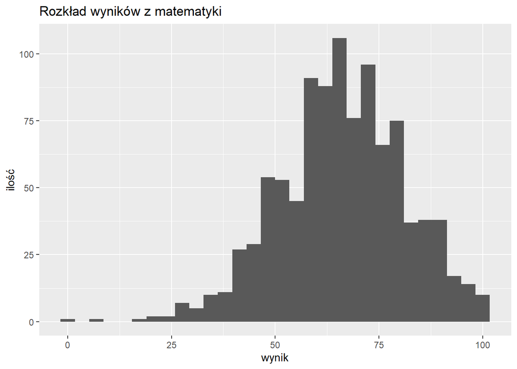

```r
# Tu umieść kod do wygenerowania odpowiedzi do zadania.
ggplot(df,aes(x=math.score))+
  geom_histogram()+
  labs(title="Rozkład wyników z matematyki",
       x="wynik",
       y="ilość")
```

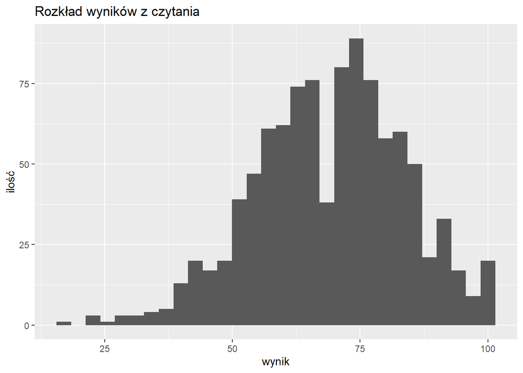

```r
ggplot(df,aes(x=reading.score))+
  geom_histogram()+
  labs(title="Rozkład wyników z czytania",
       x="wynik",
       y="ilość")
```

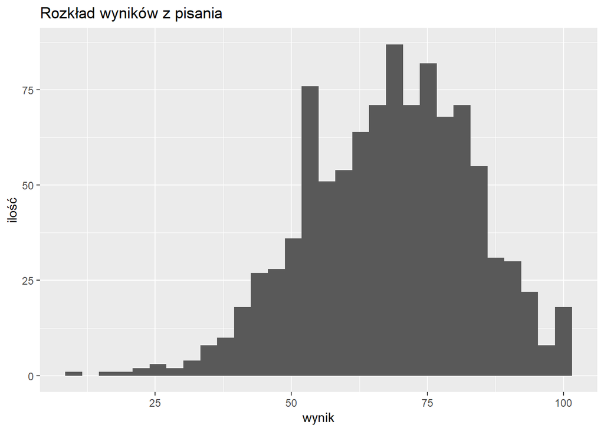

```r
ggplot(df,aes(x=writing.score))+
  geom_histogram()+
  labs(title="Rozkład wyników z pisania",
       x="wynik",
       y="ilość")
```

**Komentarz: Rozkłady wyników każdego z przedmiotów są zbliżone rozkładu normalnego, lekkim przesunięciem w stronę wyższych wyników.**

## Zadanie 2

Czy istnieje zauważalna różnica w wynikach między uczniami i uczennicami?

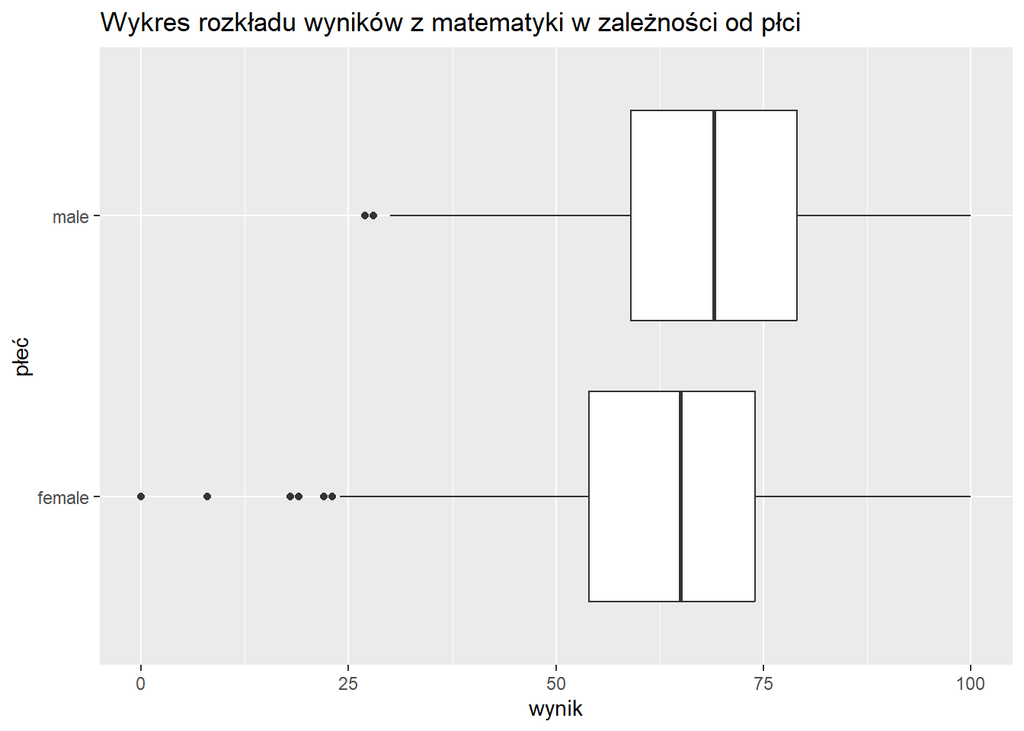

```r
# Tu umieść kod do wygenerowania odpowiedzi do zadania.
ggplot(df,aes(x=math.score,y=gender))+
  geom_boxplot()+
  labs(title="Wykres rozkładu wyników z matematyki w zależności od płci",
       x="wynik",
       y="płeć")
```

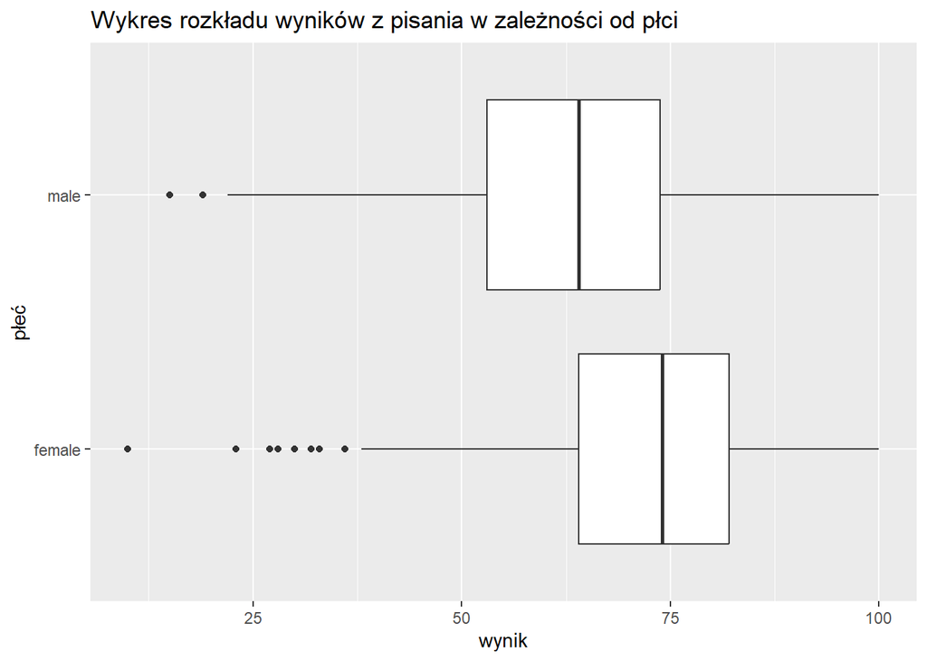

```r
ggplot(df,aes(x=writing.score,y=gender))+
  geom_boxplot()+
  labs(title="Wykres rozkładu wyników z pisania w zależności od płci",
       x="wynik",
       y="płeć")
```

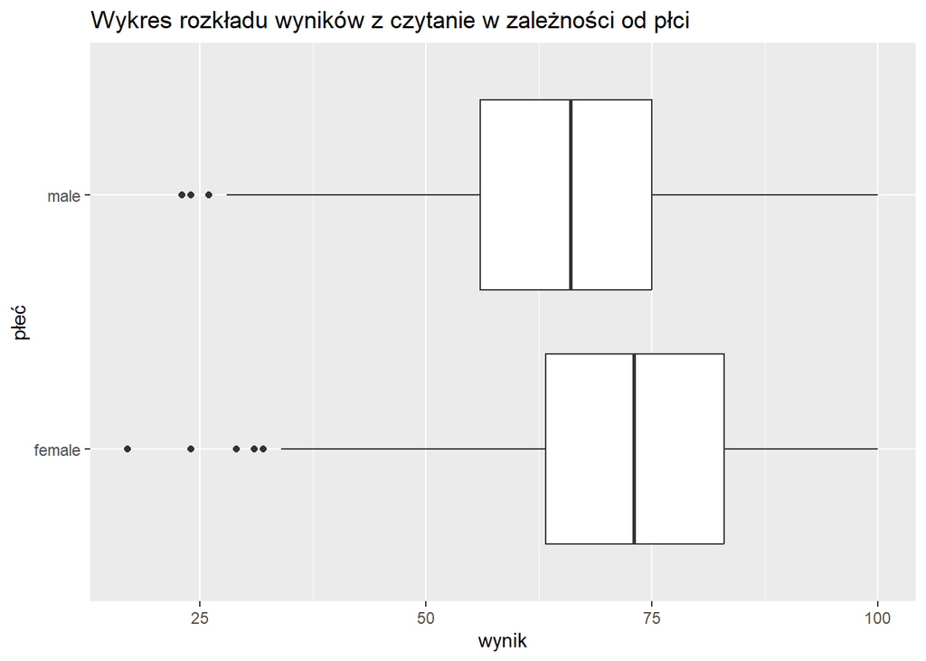

```r
ggplot(df,aes(x=reading.score,y= gender))+
  geom_boxplot()+
  labs(title="Wykres rozkładu wyników z czytanie w zależności od płci",
       x="wynik",
       y="płeć")
```

**Komentarz: Istnieje zauważalna różnica. Uczniowie uzsyskują lepsze wyniki z matematyki, natomiast uczennice lepsze wyniki z czytania i pisania.**

## Zadanie 3

Czy uczniowie, którzy ukończyli kurs przygotowawczy, osiągają lepsze wyniki niż pozostali?

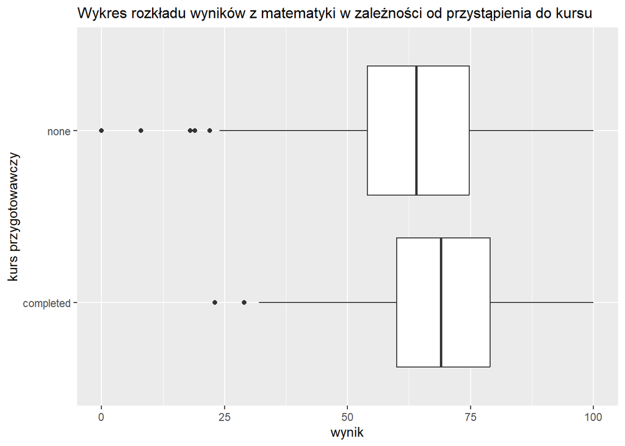

```r
# Tu umieść kod do wygenerowania odpowiedzi do zadania.
  ggplot(df,aes(x=math.score,y=test.preparation.course))+
  geom_boxplot()+
  labs(title="Wykres rozkładu wyników z matematyki w zależności od przystąpienia do kursu",
       x="wynik",
       y="kurs przygotowawczy")+
  theme(plot.title = element_text(size=12))
```

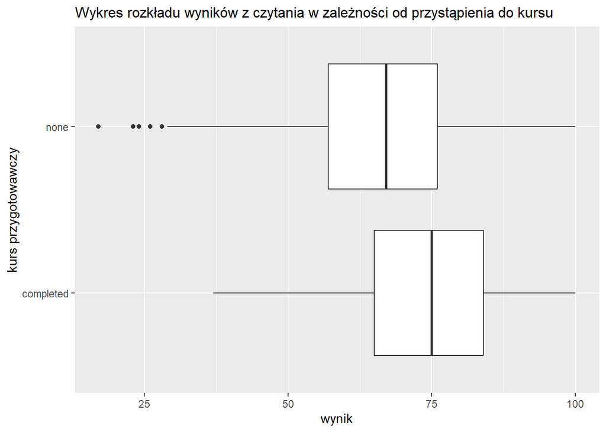

```r
ggplot(df,aes(x=reading.score,y=test.preparation.course))+
  geom_boxplot()+
  labs(title="Wykres rozkładu wyników z czytania w zależności od przystąpienia do kursu",
       x="wynik",
       y="kurs przygotowawczy")+
  theme(plot.title = element_text(size=12))
```

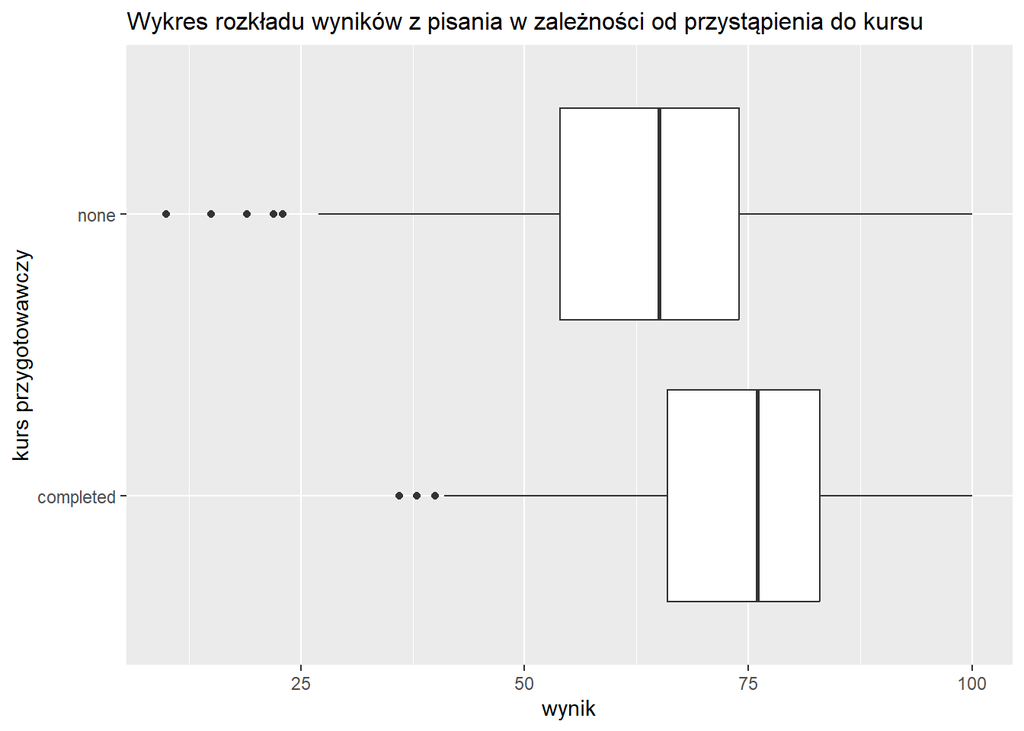

```r
ggplot(df,aes(x=writing.score,y=test.preparation.course))+
  geom_boxplot()+
  labs(title="Wykres rozkładu wyników z pisania w zależności od przystąpienia do kursu",
       x="wynik",
       y="kurs przygotowawczy")+
  theme(plot.title = element_text(size=12))
```

**Komentarz: Tak, w każdej z trzech kategorii uczniowie, którzy ukończyli kurs przygotowawczy osiągają lepsze wyniki, najmniejsza różnica w wynikach występuje w przypadku egzaminu z matematyki.**

## Zadanie 4

Jaki jest związek między poziomem wykształcenia rodziców a średnimi wynikami uczniów?

[figure not shown]

```r
# Tu umieść kod do wygenerowania odpowiedzi do zadania.
df<-df %>%
  mutate(parental.level.of.education=factor(parental.level.of.education,levels = c("master's degree","bachelor's degree","associate's degree","some college","high school","some high school")))


df %>%
  mutate(mean_score=round((math.score+reading.score+writing.score)/3,3)) %>%
  ggplot(aes(x=mean_score,y=parental.level.of.education))+
  geom_boxplot()+
  labs(title="Wykres rozkładu średniego wyniku w zależności od poziomu wykształcenia rodziców",
       x="wynik",
       y="kurs przygotowawczy")+
  theme(plot.title = element_text(size=11))
```

## Zadanie 5

Czy płeć i wykształcenie rodzica wpływa na wynik z matematyki?

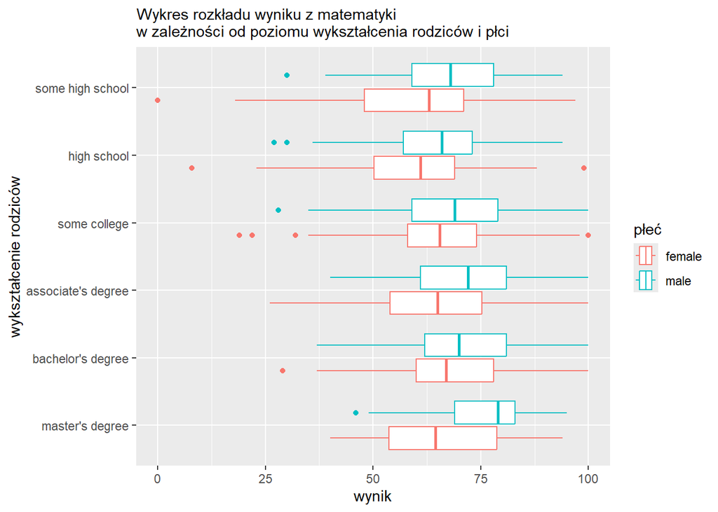

```r
# Tu umieść kod do wygenerowania odpowiedzi do zadania.
ggplot(df,aes(x=math.score,y=parental.level.of.education,color=gender))+
  geom_boxplot()+
  labs(title="Wykres rozkładu wyniku z matematyki
w zależności od poziomu wykształcenia rodziców i płci",
       x="wynik",
       y="wykształcenie rodziców",
       color="płeć")+
  theme(plot.title = element_text(size=11))
```

**Komentarz: Wyższe wykształcenie rodzica i bycie mężczyzną wiąże się z otrzymaniem lepszego wyniku z matematyki.**

## Zadanie 6

Czy istnieje zależność między wynikami z matematyki a wynikami z czytania lub pisania?

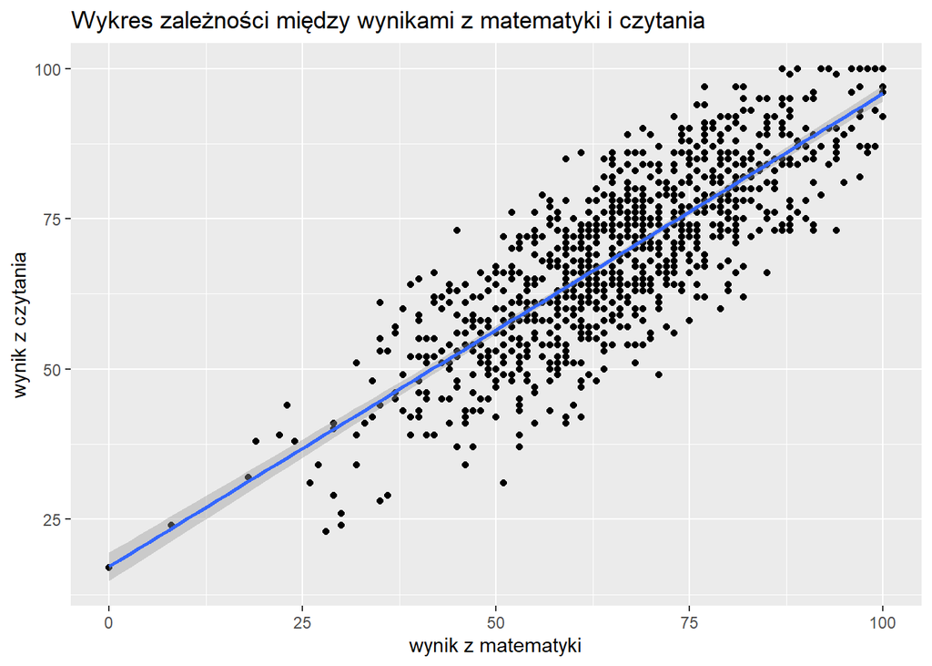

```r
# Tu umieść kod do wygenerowania odpowiedzi do zadania.
ggplot(df,aes(x=math.score,y=reading.score))+
   geom_point()+
  geom_smooth(method = "lm")+
  labs(title="Wykres zależności między wynikami z matematyki i czytania",
       x="wynik z matematyki",
       y="wynik z czytania")
```

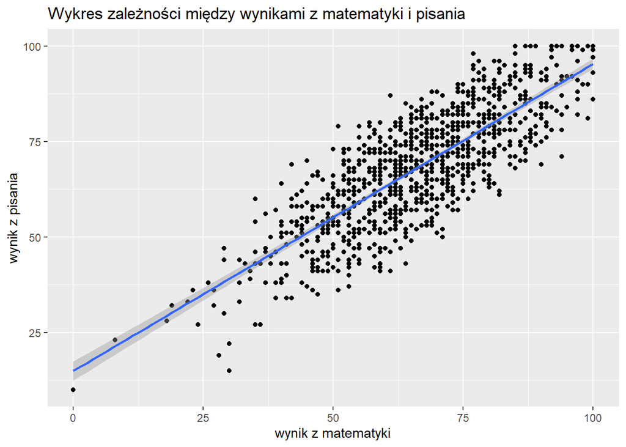

```r
  ggplot(df,aes(x=math.score,y=writing.score))+
  geom_point()+
  geom_smooth(method="lm")+
  labs(title="Wykres zależności między wynikami z matematyki i pisania",
       x="wynik z matematyki",
       y="wynik z pisania")
```